# McDuffie riots: revisiting, retelling story — 35 years later | Miami Herald

### The officers’ acquittal

Then, on Dec. 17, 1979, Arthur McDuffie ran a red light on his motorcycle past Metro Dade Sgt. Ira Diggs and took off. Diggs gave chase, as did many other police officers, and when they stopped McDuffie at North Miami Avenue and Northeast 38th Street, as many as a dozen officers beat him into a coma. He died in the hospital.

Motorists were dragged out of their cars and beaten to death. Hundreds were injured. By day two, Gov. Bob Graham called in the National Guard.

Miami activist William “D.C.” Clark remembers watching the verdict at home and then at his mother’s behest driving west through Liberty City to get his aunt and pull her out of the Lincoln Gardens apartments on 22nd Avenue, near the epicenter of the violence. He says he realized how terrible things had become when he heard someone whistle when a white couple drove by and then watched a mob shower rocks down on their sedan and drag the couple out of the stopped car and through the street.

Young and black, Clark says, he didn’t fear for his life, but “feared for my city.”

He had good reason. By nightfall, Miami was burning. Clark says the fires covered black neighborhoods in a sooty haze that reeked of rubber and fumes.

“The smell of chaos was in the air,” he said.

### Tire warehouse blaze

Some time into the late evening on May 17, Norton Pallot received a call. It was the night manager at his 24-hour tire warehouse in Brownsville. Prowlers were banging on the outside of the complex trying to get in.

Pallot said he called the police, but they were concerned only about human life, not property damage. A little while later, Pallot said, his night manager called back: “He said they’ve broken in and they’re looting the warehouse. He said they’re banging on my window.”

According to Dunn, the historian, one witness said thousands surrounded the complex, and looters broke through locked doors by backing into them repeatedly with a small car. Police did pull the night manager out, Pallot says, but his warehouse couldn’t be saved. A fire tore through the building, igniting large tires too heavy for the looters to pull out and mountains of rubber from a re-treading facility. He says there were also underground fuel tanks on site.

The blaze that followed lasted six days, according to reports in the Miami Herald, and could be seen for miles. National news carried the image across the globe. Pallot, now 90, said a friend from Uruguay called him to tell him he’d seen his building burning on the news.

“They just let the thing burn itself out. It looked as if the whole community was on fire,” Dunn said. “That was the image that flashed around the world, the Norton Tire company burning.”

When the fire started, Fields’ uncle called, worried that if the wind began to blow west the fire would jump to their homes. So they packed up their belongings and fled to a hotel.

“We were so afraid. My husband and I were here with small children. My mother and father were living at that house. We were all right here. And we didn’t know what was going to happen,” Fields said.

The wind didn’t shift, and Fields’ family homes still stand today. But the smell of burning rubber lingered and fouled the air. Fields, a certified archivist and founder of the Black Archives, scoured the site for any Norton Tire documents with historic value, but she said the blaze charred everything.

Afterward, Pallot visited the ruins of his $10 million headquarters and said he was done with Brownsville. He moved the family business to Doral, taking some 60 jobs out of the inner city and leaving behind a toxic sore that sat in the middle of Miami’s black community for years before it was cleaned up.

“That was the biggest single job loss at that tire company,” said Dunn.

Pallot, who says many of his company’s African American employees made the move to Doral, has often asked himself why his warehouse was targeted. A majority of the employees were black, he said. But he’s heard a story that circulated in the years and decades after the riot and might explain the fire. It’s repeated by Miami rapper Maurice “Trick Daddy” Young in his autobiography.

Norton Tire, he wrote, was “where cops beat and interrogated black folks during the 1960s and ’70s. Folks took pleasure in lighting that fire.”

### A hole in Brownsville

Whatever the reason, destroying the Norton Tire complex and surrounding businesses — including a hardware store, drug store and Shell gas station — ripped a hole in Brownsville. At Jet Drugs, owner Robert Rideman used to give free medications to poor families, according to Nathaniel Pruitt, a bus driver who last week talked to a reporter while visiting a Brownsville auto shop.

“When they burned his store down, that’s when the neighborhood went straight down,” said Pruitt, 62.

Adams says the destruction of a shopping center with a Sears and J.C. Penney left the community without major retail shops. And some grocery stores were destroyed, including the Adams family’s, which was irreparably damaged when police shot tear gas into the building.

Shortly after, more businesses were razed to make way for the construction of Metrorail tracks along Northwest 27th Avenue.

“There’s no place to do your shopping now. We used to be a little self-contained community with a number of neighborhood stores and services that go with them,” Adams said. “Things you take for granted.”

Attempts to rebuild the Norton Tire site haven’t been entirely wasted, but they’ve surely been troubled. Soon after the riots, the Pallot family agreed to sell the land to a community development corporation, New Washington Heights, which had plans for building a residential and commercial facility. But it took years for anything to get built, and the nonprofit was constantly accused of wasting money while yielding few results.

The county took control of the property, and in the mid ’90s, New Washington Heights was able to build and sell 18 homes on the western edge of the Norton Tire property. But its larger commercial plans were scrapped. Jackie Bell, head of the nonprofit, blames a change in county leadership, saying at one point she had Walgreens and IHOP lined up as tenants.

“In the African American community, what takes another community two years, it takes us almost 15,” she said. “For every forward step this community makes, it seems as if a thousand steps put you backwards.”

But there’s some progress in the neighborhood. The “smell of chaos” has been replaced by the scent of French fries wafting from a Checkers burger joint. New developments with hopeful names, like Renaissance and Phoenix, have gone up. Across the street, a new tire shop just opened up two weeks ago; its employees know about Norton Tire and the riots only through stories. On the opposite side of the Norton lot, Carlisle Group recently built a $100 million, 467-unit mixed-income rental project.

And as soon as next week, Miami-Dade County expects to close on a $1.5 million deal to sell the remainder of the Norton Tire property to Presidente Supermarkets, which plans to build a grocery store with apartments on top. It’s something the Brownsville community has been requesting for more than a decade.

Fields says Brownsville will never be the same. But she believes there is still hope for a revival, and life after the riots.

“It certainly isn’t the way it once was and it never will be,” she said. “But progress has been made.”

Dec. 17, 1979: At 1:15 a.m., black insurance agent Arthur McDuffie is chased on his motorcycle by Public Safety Department officers who say he ran a red light. He is stopped at North Miami Avenue and 38th Street, and severely beaten in an incident involving at least six white officers. He dies four days later.

Dec. 17: Cmdr. Dale Bowlin, senior officer at Liberty City’s police station, receives a “Use of Force Report” from the officers. “We were not satisfied,” he says.

Dec. 26: Public Safety Director Bobby Jones suspends officers Alex Marrero, Ira Diggs, Michael Watts and Charles Veverka for involvement in McDuffie’s death.

Dec. 27: Officers Herbert Evans, William Hanlon, Mark Meier, Ubaldo DelToro and Francis Mungavin are suspended.

Dec. 28: State Attorney Janet Reno files charges of manslaughter and tampering with evidence against Marrero, Diggs, Watts and Hanlon. Evans is charged with being an accessory after the fact and with evidence-tampering.

Dec. 29: McDuffie is buried.

Jan. 1, 1980: Prosecutors say Veverka and Meier have been granted immunity and will testify for the state.

Jan. 3: Demonstrators protest McDuffie’s death at the Criminal Justice Building.

Feb. 1: Reno files charges of second-degree murder against Marrero. Charges of aggravated battery are added against Diggs, Hanlon and Watts. DelToro is accused of being an accessory after the fact. Marrero is jailed.

Feb. 1: The Public Safety Department fires Marrero, Watts, Hanlon, Diggs, Meier, Veverka, DelToro and Eric Seymen, who was implicated in the cover-up. Mungavin is later suspended for 30 days.

Feb. 29: Defense attorneys request a change of venue for the trial.

March 3: Circuit Judge Lenore Nesbitt moves the case to Tampa. “This case is a time bomb,” she says.

March 28: Nesbitt dismisses two felony charges against Hanlon. Prosecutors drop lesser charges, provide Hanlon with immunity and announce that he will testify for the state.

March 31: Jury selection begins. An all-white jury eventually is chosen.

May 8: Nesbitt orders a directed verdict of acquittal for DelToro.

May 17: The case goes to the jury after almost four weeks of testimony. Two hours 45 minutes later, the jury finds Marrero, Evans, Watts and Diggs not guilty.

May 17: News of the verdict spreads in Miami. About 5 p.m., the first rocks are thrown near African Square Park. By 6 p.m., police pull back and full-scale violence breaks out in Liberty City. A protest rally is quickly organized in front of the Metro Justice complex. Soon, the violence escalates into a full-scale riot. Several police cars are burned; fires are set at government buildings. Scattered looting and fires break out in black communities all over the county. By midnight, five civilians are dead; three severely injured will die in the coming weeks.

May 18: Looting spreads. Gov. Bob Graham mobilizes 1,100 National Guardsmen, 170 Florida Highway Patrol troopers, 75 state wildlife officers and 50 Florida Marine Patrol officers. Nine more people die, either from police actions or in drive-by shootings. Lt. Edward Francis McDermott dies of a heart attack while escorting National Guardsmen. More than 270 people are treated at hospitals. Hundreds of businesses are burned, looted or destroyed.

May 19: Sporadic violence continues. Schools are closed. By evening, calm returns to the streets.

May 21: The estimate of riot damage exceeds $100 million, with at least 18 people killed and more than 400 injured during the violence.

##### Related stories from Miami Herald

### [See 1980 front page, photos of McDuffie Riots at Flashback Miami](http://flashbackmiami.com/2014/05/07/mcduffie-riots-1980/#storylink=related_inline)

May 16, 2015 3:54 PM

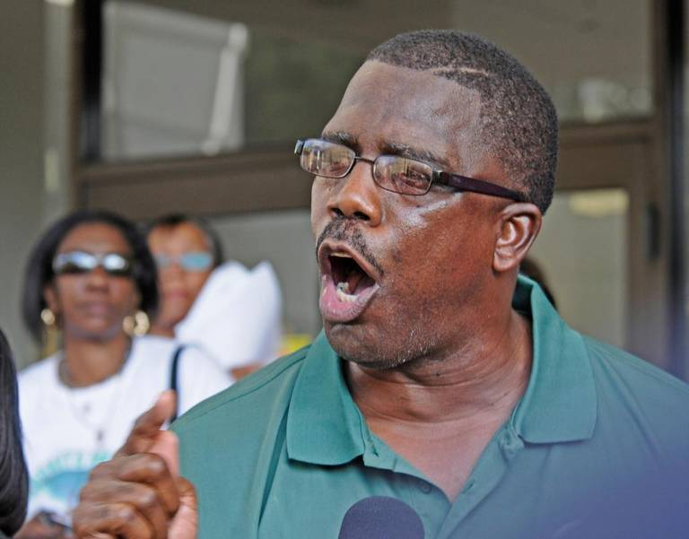

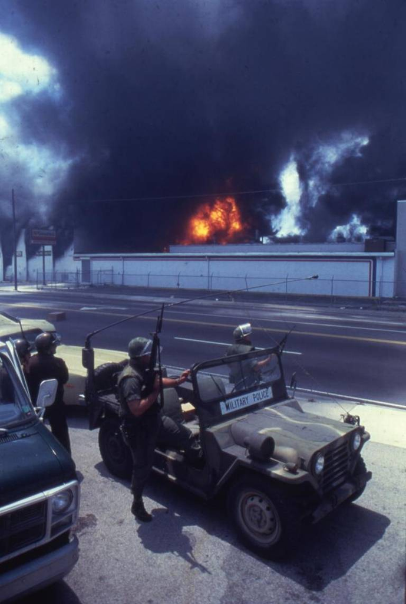

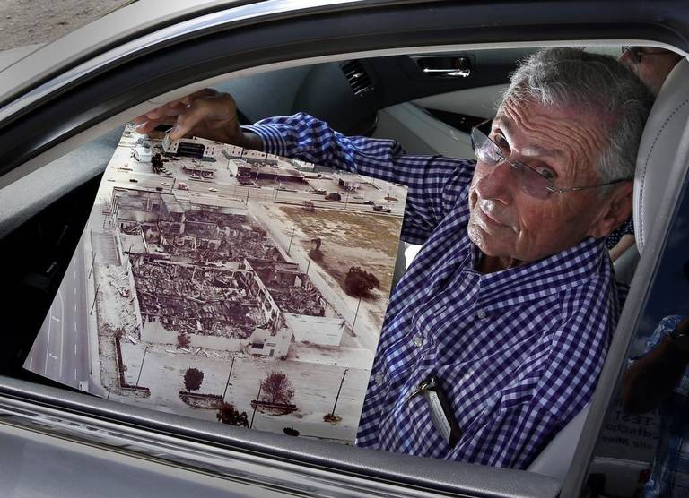

National Guardsmen take position across from burning Norton Tire Company on May 18, 1980. Bblack smoke from building at Northwest 27th Avenue and 54th Street filled the city's sky. Bruce Gilbert

[figure not shown]